# PISA Data

## Preliminary Wrangling

The Programme for International Student Assessment (PISA) is a triennial international survey which aims to evaluate education systems worldwide by testing the skills and knowledge of 15-year-old students who are nearing the end of their compulsory education. PISA assesses how well they can apply what they learn in school to real-life situations.

This dataset contains the result of the survey for 2012.

```python
# import all packages and set plots to be embedded inline
import numpy as np
import pandas as pd
import matplotlib.pyplot as plt
import seaborn as sb

%matplotlib inline

pd.set_option('display.max_columns', 636)
```

```python
pisa = pd.read_csv('pisa2012.csv', encoding='latin-1',
       index_col=0,
       dtype={15: str, 16: str, 17: str, 21: str, 22: str, 23: str, 24: str, 25: str, 26: str, 37: str,
           45: str, 65: str, 123: str, 156: str, 157: str, 158: str, 159: str, 160: str, 161: str,
           162: str, 163: str, 164: str, 165: str, 166: str, 167: str, 168: str, 169: str, 170: str,
           171: str, 284: str, 285: str, 286: str, 287: str, 288: str, 289: str, 290: str, 291: str,
           292: str, 293: str, 294: str, 295: str, 296: str, 297: str, 298: str, 299: str, 300: str,
           301: str, 302: str, 303: str, 307: str, 308: str, 309: str, 310: str, 311: str, 312: str,
           313: str, 314: str, 315: str, 316: str, 317: str, 318: str, 319: str, 320: str, 321: str,
           322: str, 323: str, 324: str, 325: str, 326: str, 327: str, 328: str, 329: str, 330: str,
           331: str, 332: str, 333: str, 334: str, 335: str, 336: str, 337: str, 338: str, 339: str,
           340: str, 341: str, 342: str, 343: str, 344: str, 345: str, 346: str, 347: str, 348: str,
           349: str, 350: str, 351: str, 352: str, 353: str, 354: str, 355: str, 356: str, 357: str,
           376: str, 377: str, 378: str, 379: str, 380: str, 381: str, 382: str, 383: str, 384: str,
           385: str, 386: str, 387: str, 388: str, 389: str, 390: str, 391: str, 392: str, 393: str,
           394: str, 395: str, 396: str, 397: str, 398: str, 399: str, 400: str, 401: str, 402: str,
           403: str, 475: str, 30: str, 31: str, 36: str, 155: str}
)
```

```python
pisa.head()
```

|  | CNT | SUBNATIO | STRATUM | OECD | NC | SCHOOLID | STIDSTD | ST01Q01 | ST02Q01 | ST03Q01 | ST03Q02 | ST04Q01 | ST05Q01 | ST06Q01 | ST07Q01 | ST07Q02 | ST07Q03 | ST08Q01 | ST09Q01 | ST115Q01 | ST11Q01 | ST11Q02 | ST11Q03 | ST11Q04 | ST11Q05 | ST11Q06 | ST13Q01 | ST14Q01 | ST14Q02 | … |
| --- | --- | --- | --- | --- | --- | --- | --- | --- | --- | --- | --- | --- | --- | --- | --- | --- | --- | --- | --- | --- | --- | --- | --- | --- | --- | --- | --- | --- | --- | --- |
| 1 | Albania | 80000 | ALB0006 | Non-OECD | Albania | 1 | 1 | 10 | 1.0 | 2 | 1996 | Female | No | 6.0 | No, never | No, never | No, never | None | None | 1.0 | Yes | Yes | Yes | Yes | NaN | NaN | <ISCED level 3A> | No | No | … |
| 2 | Albania | 80000 | ALB0006 | Non-OECD | Albania | 1 | 2 | 10 | 1.0 | 2 | 1996 | Female | Yes, for more than one year | 7.0 | No, never | No, never | No, never | One or two times | None | 1.0 | Yes | Yes | NaN | Yes | NaN | NaN | <ISCED level 3A> | Yes | Yes | … |
| 3 | Albania | 80000 | ALB0006 | Non-OECD | Albania | 1 | 3 | 9 | 1.0 | 9 | 1996 | Female | Yes, for more than one year | 6.0 | No, never | No, never | No, never | None | None | 1.0 | Yes | Yes | No | Yes | No | No | <ISCED level 3B, 3C> | Yes | Yes | … |
| 4 | Albania | 80000 | ALB0006 | Non-OECD | Albania | 1 | 4 | 9 | 1.0 | 8 | 1996 | Female | Yes, for more than one year | 6.0 | No, never | No, never | No, never | None | None | 1.0 | Yes | Yes | No | Yes | No | No | <ISCED level 3B, 3C> | No | No | … |
| 5 | Albania | 80000 | ALB0006 | Non-OECD | Albania | 1 | 5 | 9 | 1.0 | 10 | 1996 | Female | Yes, for more than one year | 6.0 | No, never | No, never | No, never | One or two times | None | 2.0 | Yes | Yes | Yes | NaN | NaN | NaN | She did not complete <ISCED level 1> | No | No | … |

```python
pisa.shape
```

```
(485490, 635)
```

### What is the structure of your dataset?

The data set contains 635 features and 485490 student survey results. So it's a very reach dataset which requires some work to understand the features (hopefully there's the dicitionnary) and then filter out the features of interest.

### What is/are the main feature(s) of interest in your dataset?

I'm interested to know what feature impact the score of the student in math, reading and science.

### What features in the dataset do you think will help support your investigation into your feature(s) of interest?

First I need the scores. Those are expressed via a set of plausible value for mathematic, reading and science: PV1MATH, PV1READ, PV1SCIE.

I expect that the parental context has an influence on the scores. So I focus on:

- the level of education of the parents (HISCED);
- the presence of the parents at home (ST11Q01: Mother at Home, ST11Q02: Father at Home)
- the work of the parents (ST15Q01: mother, ST19Q01: father)
- the time that parent spend working with the student (ST57Q05)

I wonder if cultural aspects can impact the scores and so I will consider the immigrant feature (IMMIG) to measure it.

```python
pisa = pisa[['STIDSTD','ST04Q01','CNT','PV1MATH','PV1READ','PV1SCIE','ST11Q01','ST11Q02','ST57Q05','HISCED','IMMIG']]
pisa.rename({'STIDSTD':'Student Id', 'ST04Q01':'Gender','CNT':'Country',
             'PV1MATH':'Math Score', 'PV1READ':"Reading Score",'PV1SCIE':'Science Score',
             'ST11Q01':'Mother Present', 'ST11Q02':'Father Present', 'ST57Q05':'Study Time With Parent',
             'HISCED':'Parents Highest Education', 'IMMIG':'Immigration Status'
            },
            axis='columns', inplace=True)
```

```python
pisa.head()
```

|  | Student Id | Gender | Country | Math Score | Reading Score | Science Score | Mother Present | Father Present | Study Time With Parent | Parents Highest Education | Immigration Status |
| --- | --- | --- | --- | --- | --- | --- | --- | --- | --- | --- | --- |
| 1 | 1 | Female | Albania | 406.8469 | 249.5762 | 341.7009 | Yes | Yes | NaN | ISCED 3A, ISCED 4 | Native |
| 2 | 2 | Female | Albania | 486.1427 | 406.2936 | 548.9929 | Yes | Yes | 0.0 | ISCED 5A, 6 | Native |
| 3 | 3 | Female | Albania | 533.2684 | 401.2100 | 499.6643 | Yes | Yes | 2.0 | ISCED 5A, 6 | Native |
| 4 | 4 | Female | Albania | 412.2215 | 547.3630 | 438.6796 | Yes | Yes | 0.0 | ISCED 5A, 6 | Native |
| 5 | 5 | Female | Albania | 381.9209 | 311.7707 | 361.5628 | Yes | Yes | NaN | ISCED 3A, ISCED 4 | Native |

```python
pisa.dtypes
```

```
Student Id                     int64
Gender                        object
Country                       object
Math Score                   float64
Reading Score                float64
Science Score                float64
Mother Present                object
Father Present                object
Study Time With Parent       float64
Parents Highest Education     object
Immigration Status            object
dtype: object
```

### Further Data Wrangling

#### Data assessment

```python
print(pisa.shape)
for col in pisa.columns:
    print('{} contains {} null value'.format(col, pisa[col].isna().sum()))
```

```
(485490, 11)
Student Id contains 0 null value
Gender contains 0 null value
Country contains 0 null value
Math Score contains 0 null value
Reading Score contains 0 null value
Science Score contains 0 null value
Mother Present contains 24931 null value
Father Present contains 44454 null value
Study Time With Parent contains 195988 null value
Parents Highest Education contains 12399 null value
Immigration Status contains 13697 null value
```

```python
pisa.describe()
```

|  | Student Id | Math Score | Reading Score | Science Score | Study Time With Parent |
| --- | --- | --- | --- | --- | --- |
| count | 485490.000000 | 485490.000000 | 485490.000000 | 485490.000000 | 289502.000000 |
| mean | 6134.066201 | 469.621653 | 472.004640 | 475.769824 | 1.213363 |
| std | 6733.144944 | 103.265391 | 102.505523 | 101.464426 | 2.353292 |
| min | 1.000000 | 19.792800 | 0.083400 | 2.648300 | 0.000000 |
| 25% | 1811.000000 | 395.318600 | 403.600700 | 404.457300 | 0.000000 |
| 50% | 3740.000000 | 466.201900 | 475.455000 | 475.699400 | 0.000000 |
| 75% | 7456.000000 | 541.057800 | 544.502500 | 547.780700 | 2.000000 |
| max | 33806.000000 | 962.229300 | 904.802600 | 903.338300 | 30.000000 |

```python
print(pisa.Gender.unique())
print(pisa['Mother Present'].unique())
print(pisa['Father Present'].unique())
print(pisa['Parents Highest Education'].unique())
print(pisa['Immigration Status'].unique())
```

```
['Female' 'Male']
['Yes' nan 'No']
['Yes' nan 'No']
['ISCED 3A, ISCED 4' 'ISCED 5A, 6' 'ISCED 3B, C' 'ISCED 2' 'ISCED 5B'
 'None' 'ISCED 1' nan]
['Native' nan 'Second-Generation' 'First-Generation']
```

#### Fixing missing values

To avoid any biased regarding the observations relative to parents, I prefer to drop the records containing null values. This will lead to a significant drop in the dataset however since I'm not interested by the representation of countries this does not matter.

```python
pisa_clean = pisa.dropna(subset=['Mother Present', 'Father Present', 'Study Time With Parent', 'Parents Highest Education', 'Immigration Status'])
pisa_clean.shape
```

```
(258484, 11)
```

```python
pisa_clean.head()
```

|  | Student Id | Gender | Country | Math Score | Reading Score | Science Score | Mother Present | Father Present | Study Time With Parent | Parents Highest Education | Immigration Status |
| --- | --- | --- | --- | --- | --- | --- | --- | --- | --- | --- | --- |
| 2 | 2 | Female | Albania | 486.1427 | 406.2936 | 548.9929 | Yes | Yes | 0.0 | ISCED 5A, 6 | Native |
| 3 | 3 | Female | Albania | 533.2684 | 401.2100 | 499.6643 | Yes | Yes | 2.0 | ISCED 5A, 6 | Native |
| 4 | 4 | Female | Albania | 412.2215 | 547.3630 | 438.6796 | Yes | Yes | 0.0 | ISCED 5A, 6 | Native |
| 6 | 6 | Female | Albania | 396.3312 | 378.2544 | 384.3156 | Yes | Yes | 1.0 | ISCED 3B, C | Native |
| 7 | 7 | Female | Albania | 438.0823 | 373.2503 | 508.1499 | Yes | Yes | 0.0 | ISCED 5A, 6 | Native |

#### Collate 'parents presence' into a single column

```python
pisa_clean['Parents Presence'] = ((pisa_clean['Mother Present'] == 'No') | (pisa_clean['Father Present'] == 'No')).replace(False, 'Both').replace(True, 'Single')
pisa_clean = pisa_clean.drop(['Mother Present','Father Present'], axis=1)
#pisa_clean.assign(SingleParent = (pisa_clean.MotherPresent == 'No') | (pisa_clean.FatherPresent == 'No'))
pisa_clean.head()
```

|  | Student Id | Gender | Country | Math Score | Reading Score | Science Score | Study Time With Parent | Parents Highest Education | Immigration Status | Parents Presence |
| --- | --- | --- | --- | --- | --- | --- | --- | --- | --- | --- |
| 2 | 2 | Female | Albania | 486.1427 | 406.2936 | 548.9929 | 0.0 | ISCED 5A, 6 | Native | Both |
| 3 | 3 | Female | Albania | 533.2684 | 401.2100 | 499.6643 | 2.0 | ISCED 5A, 6 | Native | Both |
| 4 | 4 | Female | Albania | 412.2215 | 547.3630 | 438.6796 | 0.0 | ISCED 5A, 6 | Native | Both |
| 6 | 6 | Female | Albania | 396.3312 | 378.2544 | 384.3156 | 1.0 | ISCED 3B, C | Native | Both |
| 7 | 7 | Female | Albania | 438.0823 | 373.2503 | 508.1499 | 0.0 | ISCED 5A, 6 | Native | Both |

#### Calculate the 'overall score'

```python
pisa_clean['Overall Score'] = (pisa_clean['Math Score'] + pisa_clean['Reading Score'] + pisa_clean['Science Score']) / 3
pisa_clean.head()
```

|  | Student Id | Gender | Country | Math Score | Reading Score | Science Score | Study Time With Parent | Parents Highest Education | Immigration Status | Parents Presence | Overall Score |
| --- | --- | --- | --- | --- | --- | --- | --- | --- | --- | --- | --- |
| 2 | 2 | Female | Albania | 486.1427 | 406.2936 | 548.9929 | 0.0 | ISCED 5A, 6 | Native | Both | 480.476400 |
| 3 | 3 | Female | Albania | 533.2684 | 401.2100 | 499.6643 | 2.0 | ISCED 5A, 6 | Native | Both | 478.047567 |
| 4 | 4 | Female | Albania | 412.2215 | 547.3630 | 438.6796 | 0.0 | ISCED 5A, 6 | Native | Both | 466.088033 |
| 6 | 6 | Female | Albania | 396.3312 | 378.2544 | 384.3156 | 1.0 | ISCED 3B, C | Native | Both | 386.300400 |
| 7 | 7 | Female | Albania | 438.0823 | 373.2503 | 508.1499 | 0.0 | ISCED 5A, 6 | Native | Both | 439.827500 |

#### Fix type issues

- StudyTimeWithParent is an int64
- Gender, ParentsHighestEducation and ImmigrationStatus are categories

```python
pisa_clean.loc[:,'Study Time With Parent'] = pisa_clean['Study Time With Parent'].astype('int64')

gender_dtype = pd.api.types.CategoricalDtype(categories=['Female','Male'])
pisa_clean.loc[:,'Gender'] = pisa_clean.Gender.astype(gender_dtype)

parents_presence_dtype = pd.api.types.CategoricalDtype(categories=['Both','Single'])
pisa_clean.loc[:,'Parents Presence'] = pisa_clean['Parents Presence'].astype(parents_presence_dtype)

parentHE_dtype = pd.api.types.CategoricalDtype(
                    categories=['None','ISCED 1','ISCED 2','ISCED 3B, C','ISCED 3A, ISCED 4','ISCED 5B','ISCED 5A, 6'],
                    ordered=True)
pisa_clean.loc[:,'Parents Highest Education'] = pisa_clean['Parents Highest Education'].astype(parentHE_dtype)

immig_dtype = pd.api.types.CategoricalDtype(categories=['Native','Second-Generation','First-Generation'], ordered=True)
pisa_clean.loc[:,'Immigration Status'] = pisa_clean['Immigration Status'].astype(immig_dtype)

pisa_clean.dtypes
```

```
Student Id                      int64
Gender                       category
Country                        object
Math Score                    float64
Reading Score                 float64
Science Score                 float64
Study Time With Parent          int64
Parents Highest Education    category
Immigration Status           category
Parents Presence             category
Overall Score                 float64
dtype: object
```

#### Check the data

```python
print(pisa_clean.Gender.unique())
print(pisa_clean['Parents Presence'].unique())
print(pisa_clean['Parents Highest Education'].unique())
print(pisa_clean['Immigration Status'].unique())
```

```
[Female, Male]
Categories (2, object): [Female, Male]
[Both, Single]
Categories (2, object): [Both, Single]
[ISCED 5A, 6, ISCED 3B, C, ISCED 3A, ISCED 4, ISCED 2, ISCED 5B, None, ISCED 1]
Categories (7, object): [None < ISCED 1 < ISCED 2 < ISCED 3B, C < ISCED 3A, ISCED 4 < ISCED 5B < ISCED 5A, 6]
[Native, Second-Generation, First-Generation]
Categories (3, object): [Native < Second-Generation < First-Generation]
```

```python
# save to a file
pisa_clean.to_csv("pisa2012_clean.csv", index=False, encoding='latin-1')
```

## Univariate Exploration

> In this section, investigate distributions of individual variables. If you see unusual points or outliers, take a deeper look to clean things up and prepare yourself to look at relationships between variables.

```python
# import all packages and set plots to be embedded inline
import numpy as np
import pandas as pd
import matplotlib.pyplot as plt
import seaborn as sb
from matplotlib.gridspec import GridSpec

%matplotlib inline

sb.set(style='white')

# Load
pisa_clean = pd.read_csv("pisa2012_clean.csv", encoding='latin-1');

# Time withe parent as int
pisa_clean.loc[:,'Study Time With Parent'] = pisa_clean['Study Time With Parent'].astype('int64')

# Parents Presence
parents_presence_dtype = pd.api.types.CategoricalDtype(categories=['Both','Single'])
pisa_clean.loc[:,'Parents Presence'] = pisa_clean['Parents Presence'].astype(parents_presence_dtype)

# Gender as category
gender_dtype = pd.api.types.CategoricalDtype(categories=['Female','Male'])
pisa_clean.loc[:,'Gender'] = pisa_clean.Gender.astype(gender_dtype)

# Parent highest level of education as category
parentHE_dtype = pd.api.types.CategoricalDtype(
                    categories=['None','ISCED 1','ISCED 2','ISCED 3B, C','ISCED 3A, ISCED 4','ISCED 5B','ISCED 5A, 6'],
                    ordered=True)
pisa_clean.loc[:,'Parents Highest Education'] = pisa_clean['Parents Highest Education'].astype(parentHE_dtype)

# Immigration as category
immig_dtype = pd.api.types.CategoricalDtype(categories=['Native','Second-Generation','First-Generation'], ordered=True)
pisa_clean.loc[:,'Immigration Status'] = pisa_clean['Immigration Status'].astype(immig_dtype)

pisa_clean.head()
```

|  | Student Id | Gender | Country | Math Score | Reading Score | Science Score | Study Time With Parent | Parents Highest Education | Immigration Status | Parents Presence | Overall Score |
| --- | --- | --- | --- | --- | --- | --- | --- | --- | --- | --- | --- |
| 0 | 2 | Female | Albania | 486.1427 | 406.2936 | 548.9929 | 0 | ISCED 5A, 6 | Native | Both | 480.476400 |
| 1 | 3 | Female | Albania | 533.2684 | 401.2100 | 499.6643 | 2 | ISCED 5A, 6 | Native | Both | 478.047567 |
| 2 | 4 | Female | Albania | 412.2215 | 547.3630 | 438.6796 | 0 | ISCED 5A, 6 | Native | Both | 466.088033 |
| 3 | 6 | Female | Albania | 396.3312 | 378.2544 | 384.3156 | 1 | ISCED 3B, C | Native | Both | 386.300400 |
| 4 | 7 | Female | Albania | 438.0823 | 373.2503 | 508.1499 | 0 | ISCED 5A, 6 | Native | Both | 439.827500 |

### Gender representation

```python
pisa_clean.Gender.value_counts()
```

```
Female    131511
Male      126973
Name: Gender, dtype: int64
```

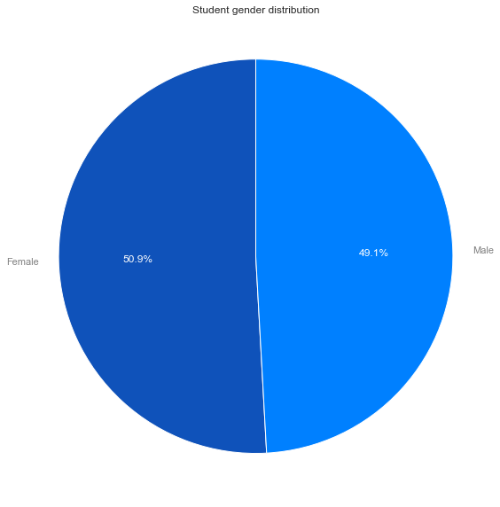

```python
fig1, ax1 = plt.subplots(1, 1, figsize=(8, 8), sharex=True)
patches, texts, autotexts = ax1.pie(pisa_clean.Gender.value_counts(),
                                    colors = ['#0f52ba','#0080ff'],
                                    labels=['Female','Male'],
                                    autopct='%1.1f%%',
                                    startangle=90
                                   );
for text in texts:
    text.set_color('grey')

for text in autotexts:
    text.set_color('white')

ax1.axis('equal');
plt.tight_layout();
plt.title('Student gender distribution')
plt.show();
```

**Student gender conlusion:**

Both genders are equivalently represented, so there's no biased in the dataset.

### Scores distribution

```python
pisa_clean[['Overall Score','Math Score','Reading Score','Science Score']].describe()
```

|  | Overall Score | Math Score | Reading Score | Science Score |
| --- | --- | --- | --- | --- |
| count | 258484.000000 | 258484.000000 | 258484.000000 | 258484.000000 |
| mean | 487.545547 | 485.028421 | 486.898391 | 490.709831 |
| std | 93.410339 | 99.256068 | 96.954522 | 96.797120 |
| min | 38.098867 | 59.284900 | 0.083400 | 20.179000 |
| 25% | 421.577092 | 413.935200 | 421.782600 | 422.920600 |
| 50% | 487.251617 | 482.325900 | 489.408800 | 491.085400 |
| 75% | 553.697550 | 553.442900 | 555.147300 | 559.250300 |
| max | 875.868167 | 962.229300 | 904.802600 | 903.338300 |

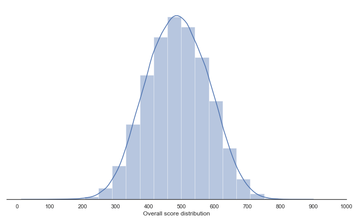

```python
f, axes = plt.subplots(1, 1, figsize=(12, 7), sharex=True)
sb.despine(left=True)
sb.distplot(pisa_clean['Overall Score'], bins=20);

x_ticks = np.arange(0, 1000 + 1, 100)
plt.xticks(x_ticks, x_ticks);
plt.setp(axes, yticks=[]);
plt.xlabel('Overall score distribution');
```

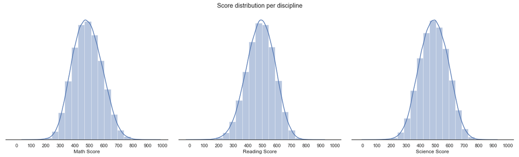

```python
f, axes = plt.subplots(1, 3, figsize=(17, 5), sharex=True)
sb.despine(left=True)

sb.distplot(pisa_clean['Math Score'], ax=axes[0], bins=20)
sb.distplot(pisa_clean['Reading Score'], ax=axes[1], bins=20)
sb.distplot(pisa_clean['Science Score'], ax=axes[2], bins=20)

x_ticks = np.arange(0, 1000 + 1, 100)
plt.xticks(x_ticks, x_ticks);
plt.setp(axes, yticks=[])
plt.tight_layout()
plt.suptitle('Score distribution per discipline', y=1.02)
plt.show();
```

**Scores distribution findings:**

- All the score are normally distributed
- Most of the students' scores are between 350 and 650 points.
- The mean of the distribution is very close to 500 points which is also the mean of the evalution scale. This indicate a well balanced evaluation.

### Immigration status

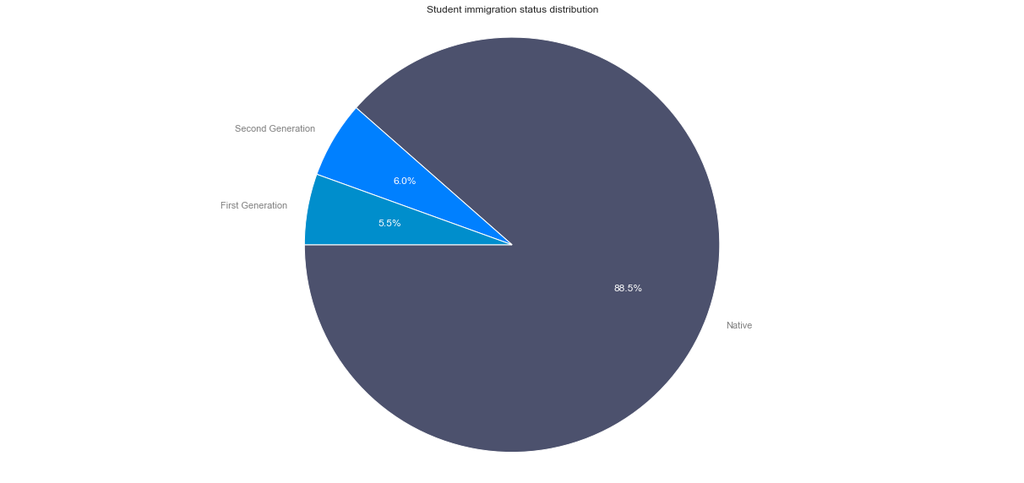

```python
fig1, ax1 = plt.subplots(1, 1, figsize=(17, 8), sharex=True)
patches, texts, autotexts = ax1.pie(pisa_clean['Immigration Status'].value_counts(),
                                    colors = ['#4c516d','#0080ff','#008ecc'],
                                    labels=['Native', 'Second Generation', 'First Generation'],
                                    autopct='%1.1f%%',
                                    startangle=180
                                   );
for text in texts:
    text.set_color('grey')

for text in autotexts:
    text.set_color('white')

ax1.axis('equal');
plt.tight_layout();
plt.title('Student immigration status distribution')
plt.show();
```

**Immigration Status findings**:

- Most of the students are native
- First and second generation immigrants are equivalently reprensented in the dataset

### Parents highest education level

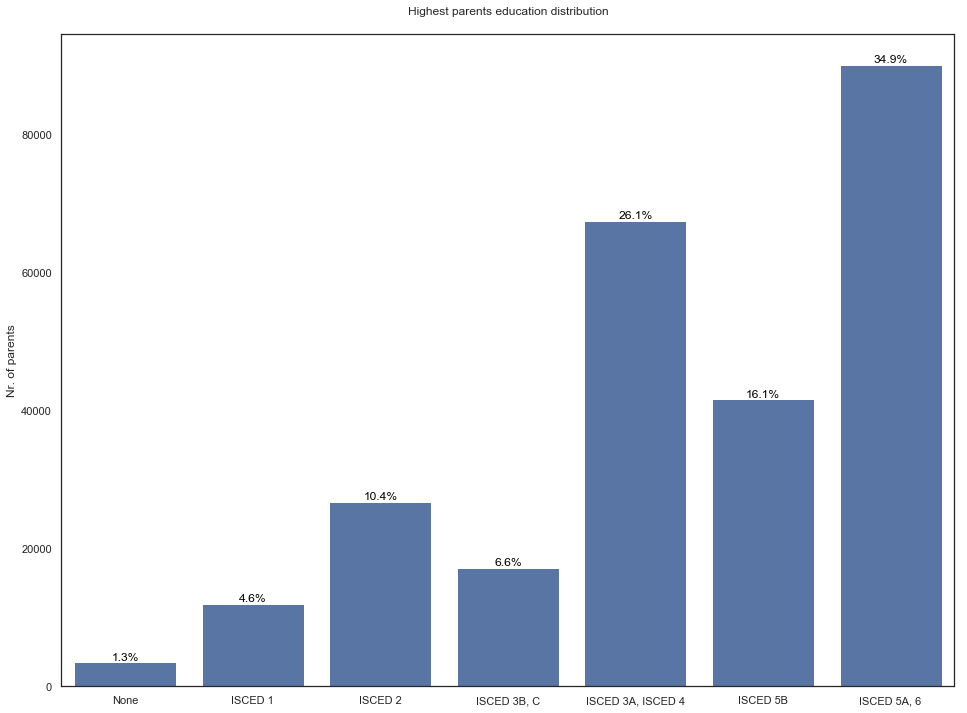

```python
plt.figure(figsize=[16, 12]);
sb.countplot(x = 'Parents Highest Education', data = pisa_clean, color = sb.color_palette()[0]);

# add annotations
n_points = pisa_clean.shape[0]
cat_counts = pisa_clean['Parents Highest Education'].value_counts()
locs, labels = plt.xticks() # get the current tick locations and labels

# loop through each pair of locations and labels
for loc, label in zip(locs, labels):

    # get the text property for the label to get the correct count
    count = cat_counts[label.get_text()]
    pct_string = '{:0.1f}%'.format(100*count/n_points)

    # print the annotation just below the top of the bar
    plt.text(loc, count-8, pct_string, ha = 'center', va='bottom', color = 'black')

plt.ylabel('Nr. of parents');
plt.xlabel('');
plt.title('Highest parents education distribution', y = 1.02);
```

**Parent level of eduction conlusion:**

### Study time with parents

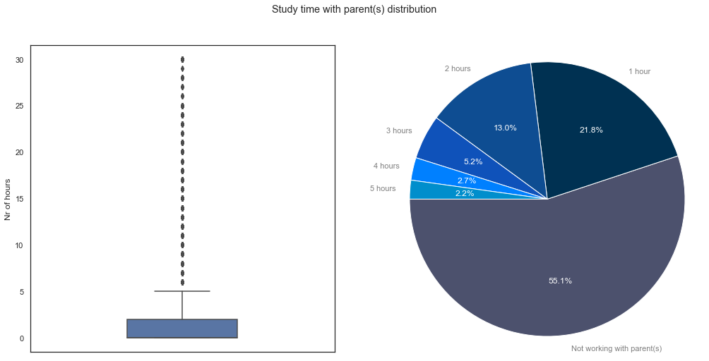

```python
fig1, ax1 = plt.subplots(1, 2, figsize=(17, 8), sharex=True)

sb.boxplot(x=pisa_clean['Study Time With Parent'], orient='v', ax=ax1[0]);
ax1[0].set(ylabel='Nr of hours')

patches, texts, autotexts = ax1[1].pie(pisa_clean[pisa_clean['Study Time With Parent'] < 6]['Study Time With Parent'].value_counts(),
                                    colors = ['#4c516d','#003152','#0e4d92','#0f52ba','#0080ff','#008ecc'],
                                    labels=['Not working with parent(s)', '1 hour', '2 hours', '3 hours', '4 hours', '5 hours'],
                                    autopct='%1.1f%%',
                                    startangle=180
                                   );
for text in texts:
    text.set_color('grey')
for text in autotexts:
    text.set_color('white')
ax1[1].axis('equal');

plt.suptitle('Study time with parent(s) distribution')
plt.show();
```

**Study time with parents findings:**

- Some students work up to 30 hours with their parent(s).
- Students working more than 5 hours with their parent(s) is very rare.
- The majority of the students don't work with their parents.
- A significant part of the students work with their parents.

### Parent presence

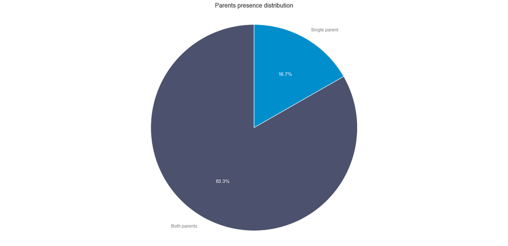

```python
fig1, ax1 = plt.subplots(1, 1, figsize=(17, 8), sharex=True)
patches, texts, autotexts = ax1.pie(pisa_clean['Parents Presence'].value_counts(),
                                    colors = ['#4c516d','#008ecc'],
                                    labels=['Both parents','Single parent'],
                                    autopct='%1.1f%%',
                                    startangle=90
                                   );
for text in texts:
    text.set_color('grey')

for text in autotexts:
    text.set_color('white')

ax1.axis('equal');
plt.tight_layout();
plt.suptitle('Parents presence distribution', y=1.02)
plt.show();
```

**Single parent family findings**:

- A significant part of the families are single parent

## Bivariate Exploration

> In this section, investigate relationships between pairs of variables in your data. Make sure the variables that you cover here have been introduced in some fashion in the previous section (univariate exploration).

### Immigration status and scores

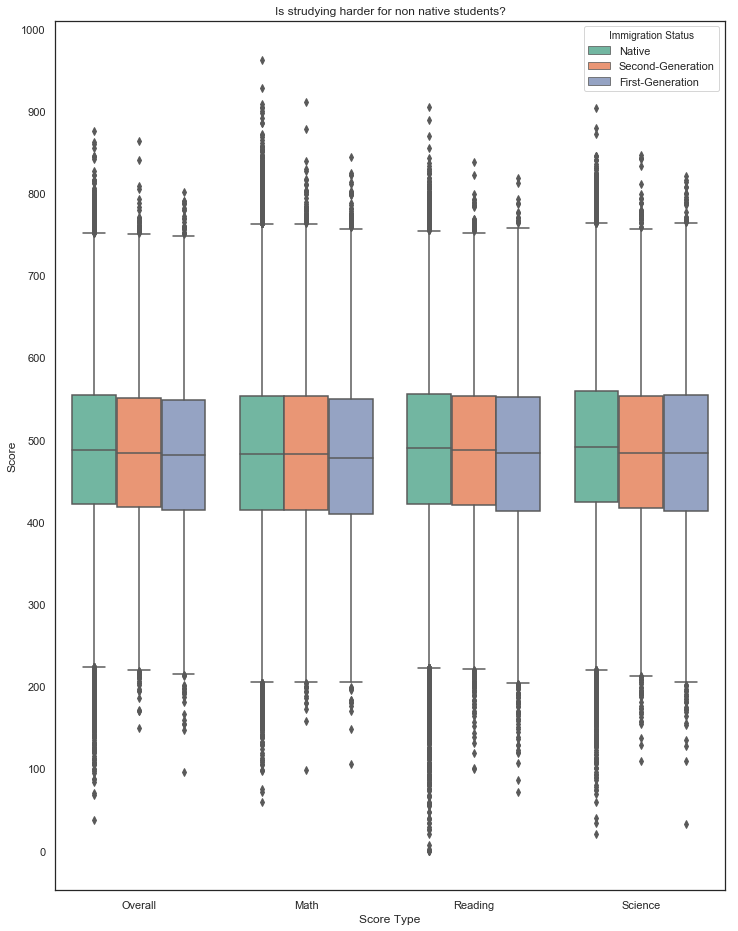

```python
data = pd.melt(pisa_clean, id_vars=['Student Id', 'Gender', 'Country', 'Study Time With Parent', 'Parents Highest Education', 'Immigration Status', 'Parents Presence'],
               value_vars=['Overall Score','Math Score','Reading Score','Science Score'],
               var_name="Score Type", value_name='Score')
data['Score Type'] = data['Score Type'].replace('Overall Score', 'Overall').replace('Math Score','Math').replace('Reading Score','Reading').replace('Science Score','Science')

plt.figure(figsize=[12, 16]);
sb.boxplot(x = data['Score Type'], y = data['Score'], hue=data['Immigration Status'], palette = 'Set2')
plt.title('Is strudying harder for non native students?');
y_ticks = np.arange(0, 1000 + 1, 100)
plt.yticks(y_ticks, y_ticks);
```

**Immigration status and scores findings:**

- From an overall score point of view, studying seems slighly harder for non native students but the difference in score remains very low.
- In Math, scores are similar between native and second generation strudents while the one for first generation is a bit less. This may be due to the abstract nature of mathematics (where the literary matters less). Afterall mathematics is oftenly quoted as the universal language.

### Parent level education and scores

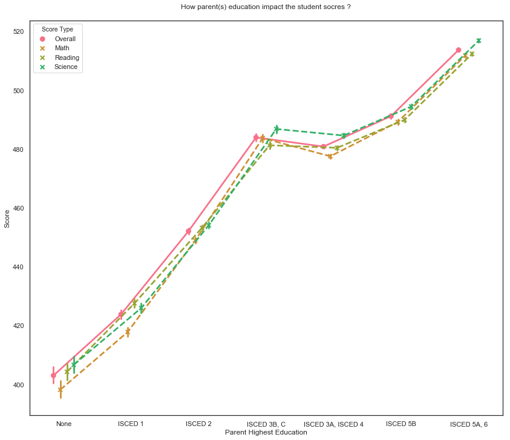

```python
#parents_he_scores = pisa_clean.groupby(['Parents Highest Education']).mean().reset_index()[['Parents Highest Education','Overall Score','Math Score','Reading Score','Science Score']]
parents_he_scores = pisa_clean[['Parents Highest Education','Overall Score','Math Score','Reading Score','Science Score']]
parents_he_scores.rename({'Overall Score':'Overall', 'Math Score':'Math', 'Reading Score':'Reading', 'Science Score':'Science'},axis=1, inplace=True)
data = pd.melt(parents_he_scores, id_vars=['Parents Highest Education'],
               value_vars=['Overall','Math','Reading','Science'],
               var_name="Score Type", value_name='Score Value')

fig, ax = plt.subplots(1, 1, figsize=(14, 12))

ax = sb.pointplot(ax=ax, data = data,
                  x = 'Parents Highest Education', y='Score Value', hue='Score Type',
                  dodge=0.3, palette=sb.color_palette('husl', 8),
                  markers=["o", "x","x","x"], linestyles=["-", "--", "--", "--"]);
#ax = sb.pointplot(ax=ax, data = pisa_clean, x = 'Parents Highest Education', y='Overall Score', hue='Parents Presence', markers=["o", "x","x","x"], linestyles=["-", "--", "--", "--"]);
ax.set(xlabel='Parent Highest Education', ylabel='Score')
plt.title("How parent(s) education impact the student socres ?", y=1.02);
```

### Study time with parent(s) and scores

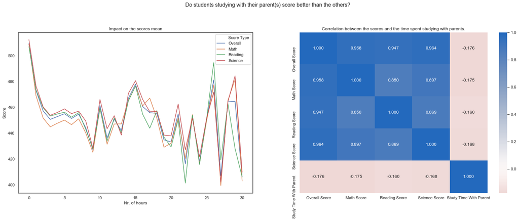

```python
scores = pisa_clean.groupby(['Study Time With Parent']).mean().reset_index()[['Study Time With Parent','Overall Score','Math Score','Reading Score','Science Score']]
scores.rename({'Overall Score':'Overall', 'Math Score':'Math', 'Reading Score':'Reading', 'Science Score':'Science'}, axis=1, inplace=True)
data = pd.melt(scores, id_vars=['Study Time With Parent'],
               value_vars=['Overall','Math','Reading','Science'],
               var_name="Score Type", value_name='Score')

fig, ax = plt.subplots(1, 2, figsize=(25, 8))

sb.lineplot(ax=ax[0], data = data,
            x = 'Study Time With Parent', y='Score', hue='Score Type'
           );
ax[0].set(title='Impact on the scores mean', xlabel='Nr. of hours', ylabel='Score')

sb.heatmap(pisa_clean[['Overall Score','Math Score','Reading Score', 'Science Score', 'Study Time With Parent']].corr(), annot = True, fmt = '.3f',
           cmap = 'vlag_r', center = 0)
ax[1].set(title='Correlation between the scores and the time spent studying with parents.')

plt.suptitle("Do students studying with their parent(s) score better than the others?", y=1.02);
```

**Study time with parent(s) and scores findings:**

- First let's remember from the univariate exploration that it's very rare that students spend more than 5 hours sudying with their parent(s).
- From the visualization of the scores mean, we see that:
  - when considering only number of hours between 0 and 5, there's a significant drop of about 70 points in the score so studying with parents does not seems to be a factor of success.
  - after 5 hours, the pattern is quite erratic and time spent can have huge impact (negative or positive) on the socres. We can just raise a question about why spending so much time, may be this concerns only students having difficulties and so getting help from their parent(s). We will furhter investigate with 'Parent Presence' to see if single parent have more difficulties to help their children.
- From the visualization correlations, we get the confirmation that there's a weak negative correlation between scores and study time with parent. This looks normal since we expect of students from that age to be autonomous.

### Single parent and scores

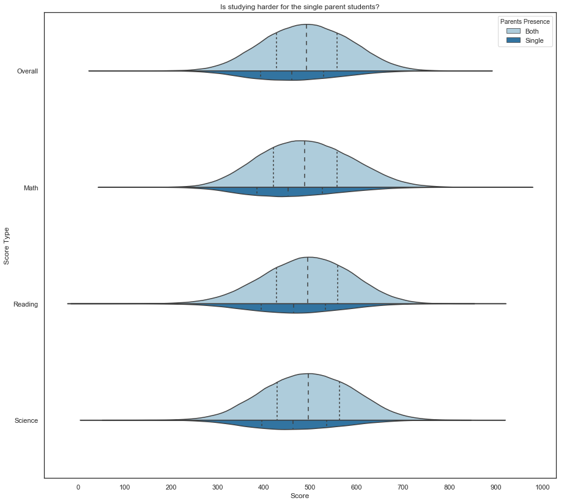

```python
data = pd.melt(pisa_clean, id_vars=['Student Id', 'Gender', 'Country', 'Study Time With Parent', 'Parents Highest Education', 'Immigration Status', 'Parents Presence'],
               value_vars=['Overall Score','Math Score','Reading Score','Science Score'],
               var_name="Score Type", value_name='Score')
data['Score Type'] = data['Score Type'].replace('Overall Score', 'Overall').replace('Math Score','Math').replace('Reading Score','Reading').replace('Science Score','Science')

palette = sb.color_palette("Paired")

plt.figure(figsize = [15, 14])
ax = sb.violinplot(x = 'Score', y='Score Type', hue='Parents Presence',
                   data=data, palette=palette, split=True,
                   scale="count", inner="quartile");

x_ticks = np.arange(0, 1000 + 1, 100)
plt.xticks(x_ticks, x_ticks);
plt.title("Is studying harder for the single parent students?");
```

## Multivariate Exploration

Since I'm mainly interested in the impact of the parents on the scores, I want to investigate furhtermore by crossing several observations with the Parent Presence.

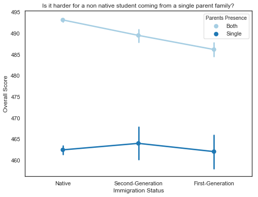

```python
plt.figure(figsize = [8, 6])

ax = sb.pointplot(data = pisa_clean,
                  x = 'Immigration Status', y = 'Overall Score', hue = 'Parents Presence',
                  palette = sb.color_palette("Paired")
                 );

plt.title('Is it harder for a non native student coming from a single parent family?');
```

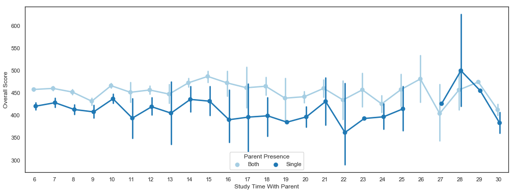

```python
plt.figure(figsize = [17, 6])

#ax = sb.barplot(data = pisa_clean[pisa_clean['Study Time With Parent'] > 5], x = 'Study Time With Parent', y = 'Overall Score', hue = 'Parents Presence')
ax = sb.pointplot(data = pisa_clean[pisa_clean['Study Time With Parent'] > 5],
                  x = 'Study Time With Parent', y = 'Overall Score', hue = 'Parents Presence',
                  dodge = 0.1, palette = sb.color_palette('Paired')
                 )
ax.legend(loc = 8, ncol = 3, framealpha = 1, title = 'Parent Presence');
```

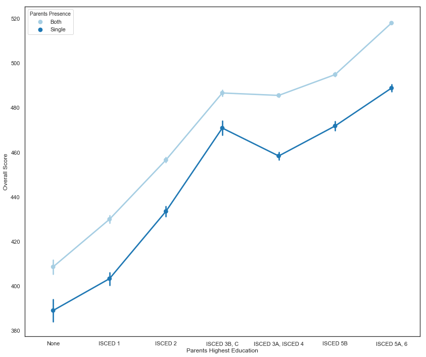

```python
plt.figure(figsize = [14, 12])
ax = sb.pointplot(data = pisa_clean,
                  x = 'Parents Highest Education', y='Overall Score', hue='Parents Presence',
                  palette = sb.color_palette("Paired"));
```